# Estimating Access to Rabies Post-Exposure Prophylaxis in Madagascar

Malavika Rajeev

July 18th, 2018

#### Canine rabies

- Annually, an estimated 60,000 people die from canine rabies.
- These deaths are preventable if people receive prompt post-exposure prophylaxis
- In places where rabies is endemic, there are significant barriers to accessing PEP (i.e. socioeconomics, availability)
- In Madagascar, rabies is endemic, however surveillance is poor and little data is available. There are 31 clinics, or CTAR (centre de traitment antirabique), that provide post-exposure prophylaxis in the country (Figure 1).

[figure not shown]

Figure 1

### Preliminary data from the Moramanga District

- Commune level average travel time to the closest CTAR (generated from global travel time layer from Malaria Atlas Project).
- Human population per commune extracted from World Pop
- 16 months of data on reported animal bites from the Moramanga District in Madagascar
- In the next month, we will have 4 years of data on reported animal bites from 20 of the 31 CTAR.

#### Rationale

Standard decision tree models using overall reported bites would estimate rabies exposures ($R$) as:
$$R = \frac{B\times p_{rabid}}{\rho }$$

where $B$ is the total reported bites, $p_{rabid}$ is the probability that a reported animal bite is a genuine rabies exposure, $\rho$ is the probability that a rabies exposure is reported.

We generate high and low estimates of expected rabies incidence ($R$) using outputs from a recent modeling study that estimated incidence of human exposures per 100,000 dogs in a no-vaccination scenario and given high and low estimates of human:dog ratios. We can do this in Madagascar because there’s no vacc going on!

Applying this framework to our data on reported bites in the Moramanga District, we see that estimated rabies incidence exceeds expected incidence in areas with high incidence of reported bites and is lower than expected for areas with little data/low incidence of reported bites (Figure 1).

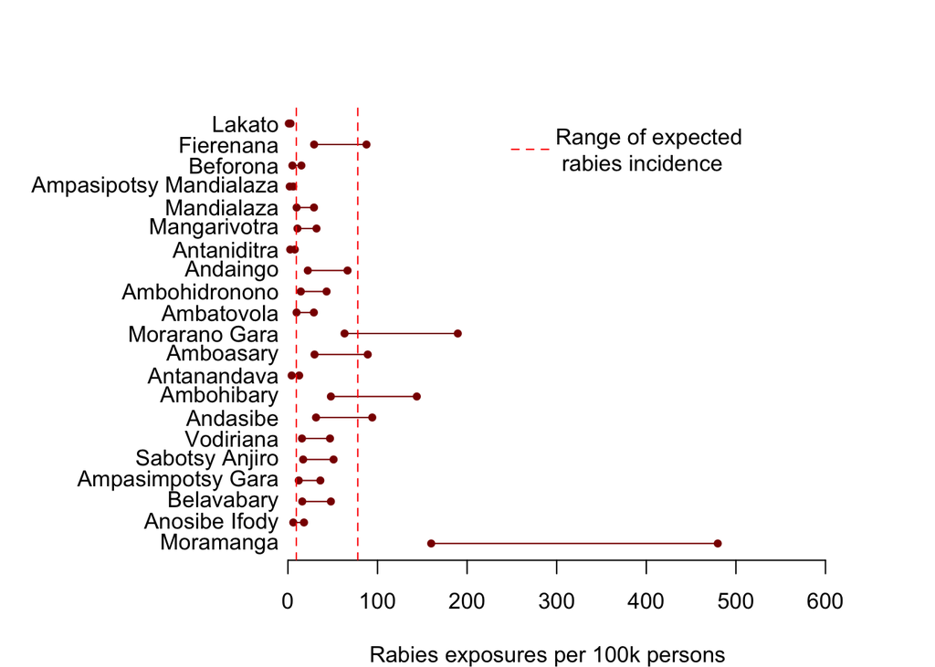

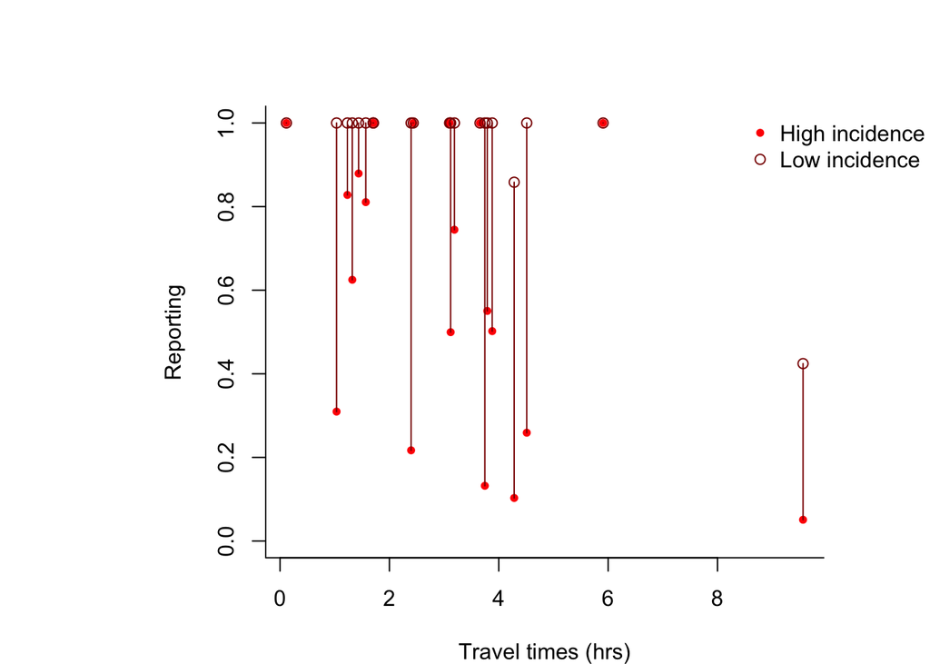

#### Empirical estimates of p_report for each location across a range of scenarios

We can calculate p_report empirically assuming incidence and p_rabid is uniform:
$$\rho = \frac{B\times p_{rabid}}{R}$$

We constrain $p_{rabid}$ so that $\rho$ cannot exceed 1:
$$p_{rabid}=
\begin{cases}
1, & \text{if}\ \frac{R}{B} > 1 \\
\frac{R}{B}, & \text{otherwise}
\end{cases}$$
which would give us the highest estimates of reporting for a given incidence level (assumes that the maximum # of bites are reported the $\frac{R}{B} > 1$ and that reporting = 1 when $\frac{R}{B} < 1$). We see that generally reporting decreases with travel time, although this relationship will depend on our assumptions of incidence and $p_{rabid}$ (Figure 2).

#### Models of reporting by travel time to clinic

To generate more probable estimates of rabies burden given what we know about access to PEP in Maadagascar, we estimate a commune specific reporting rate as a function of travel time ($T$) to the nearest ARMC given an expected rabies exposures incidence and corresponding $p_{rabid}$:

$$B \sim Poisson(\frac{\rho R}{p_{rabid}})$$
$$\rho = logistic(B_{tt}T+ B_{0})$$
$$p_{rabid}=
\begin{cases}
x, & \text{if}\ \frac{R}{B} > x \\
\frac{R}{B}, & \text{otherwise}
\end{cases}$$

We estimate the potential relationship between travel time and reporting ($B_{tt}$ and $B_{0}$) given high and low estimates of incidence and high, mid, and low proportion rabid ($x$ = 0.25, 0.5, or 0.75).

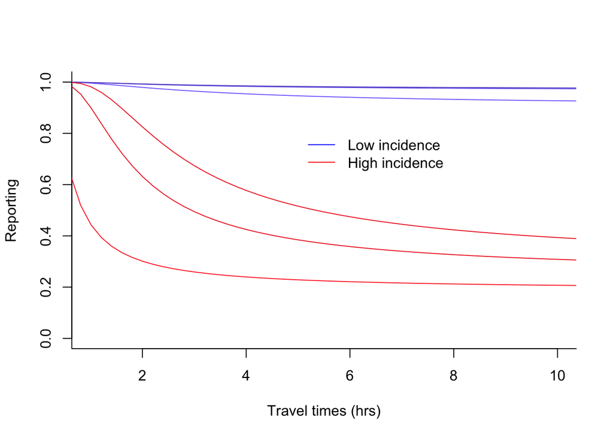

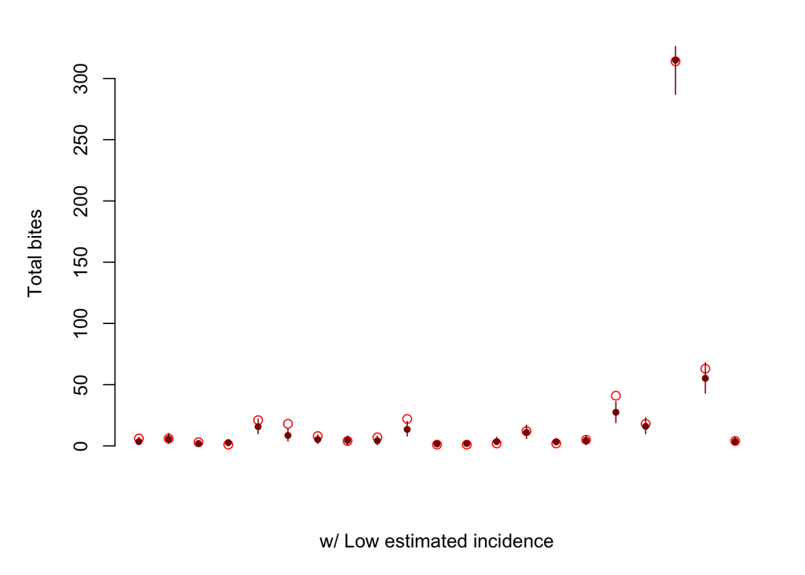

#### Estimating

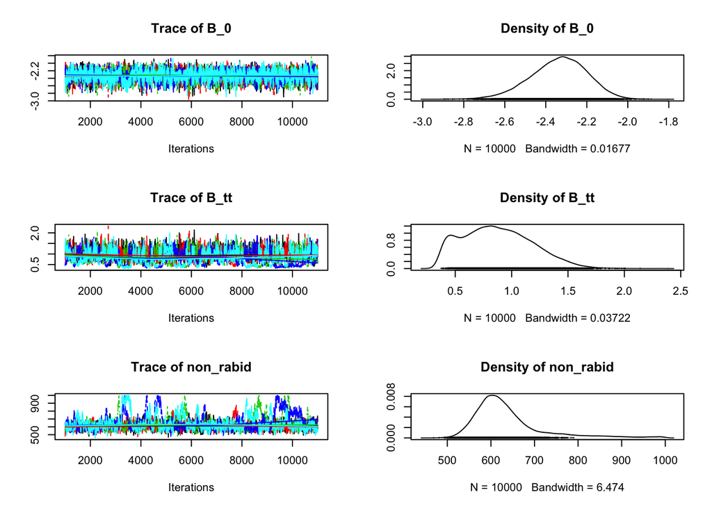

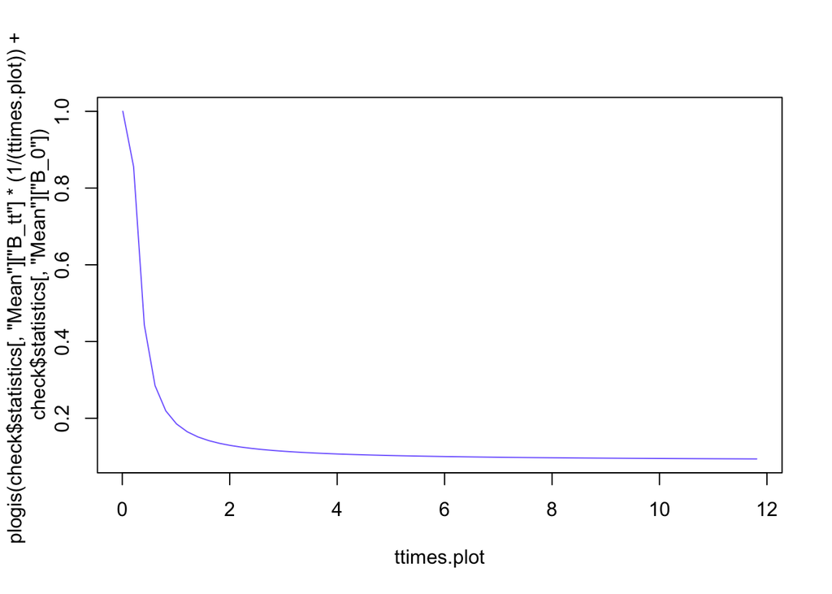

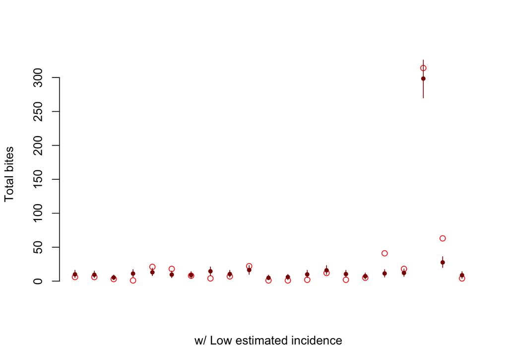